# R Notebook

```r
library(tidyverse)
```

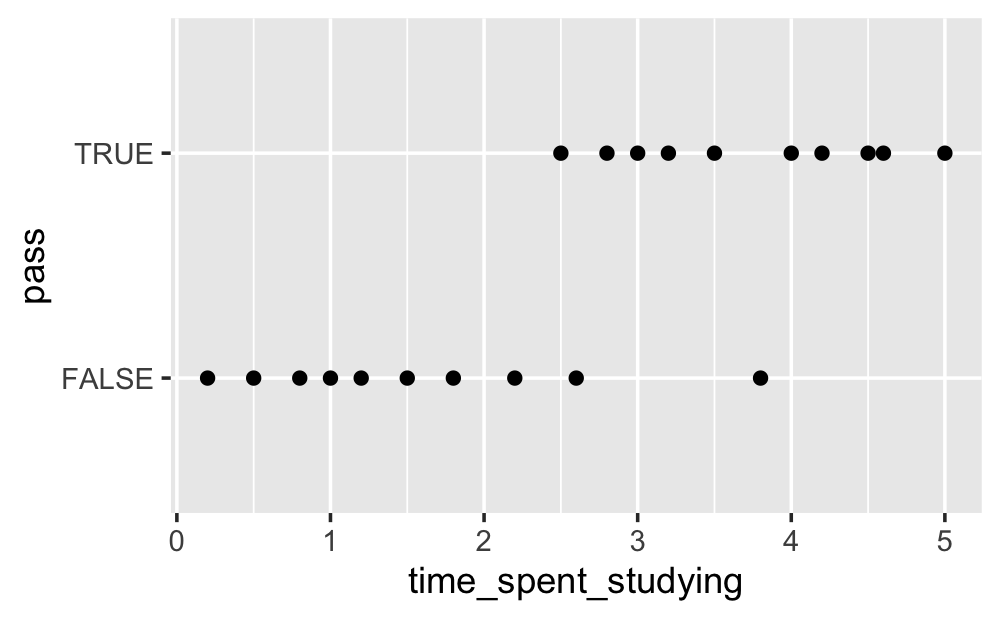

why doesn’t l reg work ?

can predict outside of the range High error

instead a fit we might want would

predict a prob of pass/fail (always be between 0 and 1 ) would closely align with data points

- How do we do this?

we need to talk about odds

odd is a ratio of success : failure

odds of tossing a coin and getting a head 1 success (head) 1 failure (tail) 1:1

1:5

used as classification technique (binary)

```r
mortgage <- read_csv('data/mortgage_applications.csv') %>% janitor::clean_names()
```

| tu_score | employed | age | accepted |
| --- | --- | --- | --- |
| 433 | TRUE | 28 | TRUE |
| 93 | TRUE | 52 | FALSE |
| 368 | FALSE | 63 | FALSE |
| 665 | TRUE | 42 | TRUE |
| 687 | TRUE | 38 | TRUE |
| 594 | TRUE | 27 | FALSE |
| 83 | FALSE | 24 | FALSE |
| 172 | TRUE | 19 | FALSE |
| 27 | FALSE | 45 | FALSE |
| 232 | FALSE | 34 | FALSE |

[output cut: 990 more lines]

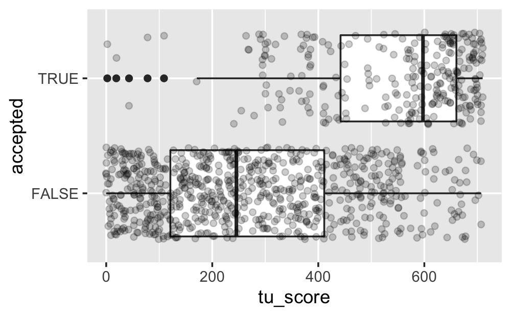

a glossary of terms probability = p_1/p_all odds = p_1/p_not_1 odds ratio ln/log log odds = log of the odds eg.log(0.2) link function logit odds factor

```r
logit <- function(x){
  return(log(x/(1-x)))
}

logit_data <- tibble(p = seq(0.001, 0.999, 0.001)) %>%
  mutate(logit_p = logit(p))
head(logit_data)
```

| p | logit_p |
| --- | --- |
| 0.001 | -6.906755 |
| 0.002 | -6.212606 |
| 0.003 | -5.806138 |
| 0.004 | -5.517453 |
| 0.005 | -5.293305 |
| 0.006 | -5.109978 |

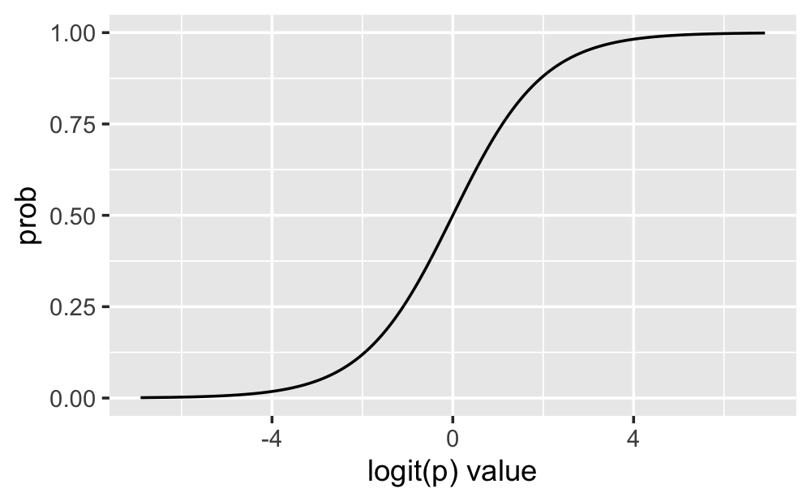

```r
library(janitor)
```

```r
summary(mod_md)
```

```
Call:
glm(formula = accepted ~ tu_score, family = binomial(link = "logit"),
    data = mortgage)

Deviance Residuals:
    Min       1Q   Median       3Q      Max
-1.8077  -0.6087  -0.2703   0.6851   3.0227

Coefficients:
             Estimate Std. Error z value Pr(>|z|)
(Intercept) -4.575035   0.285035  -16.05   <2e-16 ***
tu_score     0.008475   0.000566   14.97   <2e-16 ***
---
Signif. codes:  0 ‘***’ 0.001 ‘**’ 0.01 ‘*’ 0.05 ‘.’ 0.1 ‘ ’ 1

(Dispersion parameter for binomial family taken to be 1)

    Null deviance: 1170.48  on 999  degrees of freedom
Residual deviance:  792.14  on 998  degrees of freedom
AIC: 796.14

Number of Fisher Scoring iterations: 5
```

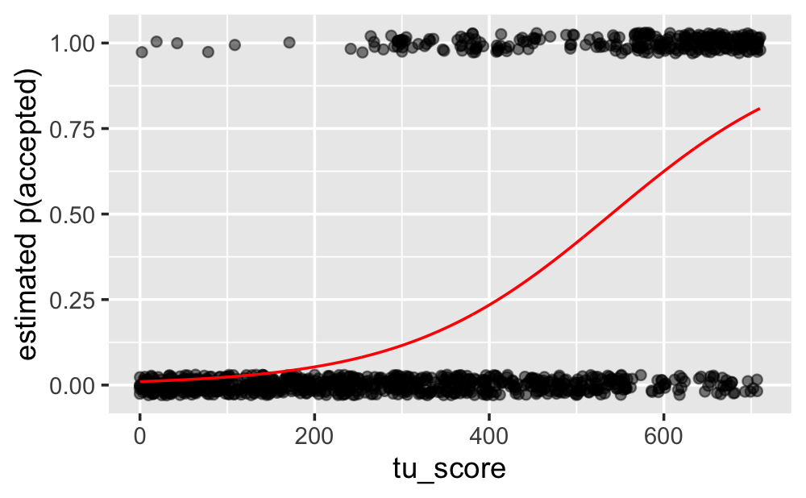

| tu_score | pred |
| --- | --- |
| 600 | 0.6247912 |

how do our odds of getting accepted for a mortage change as we increase tu_score?

odda at a baseline level (tu_score = 594) odds at a bit above the baseline level

how does increasing our tu_score by 50 affect our data

```r
odds_change <- function(b1, change){
  exp(b1 * change)
}

odds_change(0.008475, 50)
```

```
[1] 1.52768
```

a 50 unit increase in tu_score, increase our odds by a factor of 1.53

next is categorical predictor

```r
mod_2 <- glm(
  accepted ~ tu_score + employed,
  family = binomial(link = 'logit'),
  data = mortgage
)
```

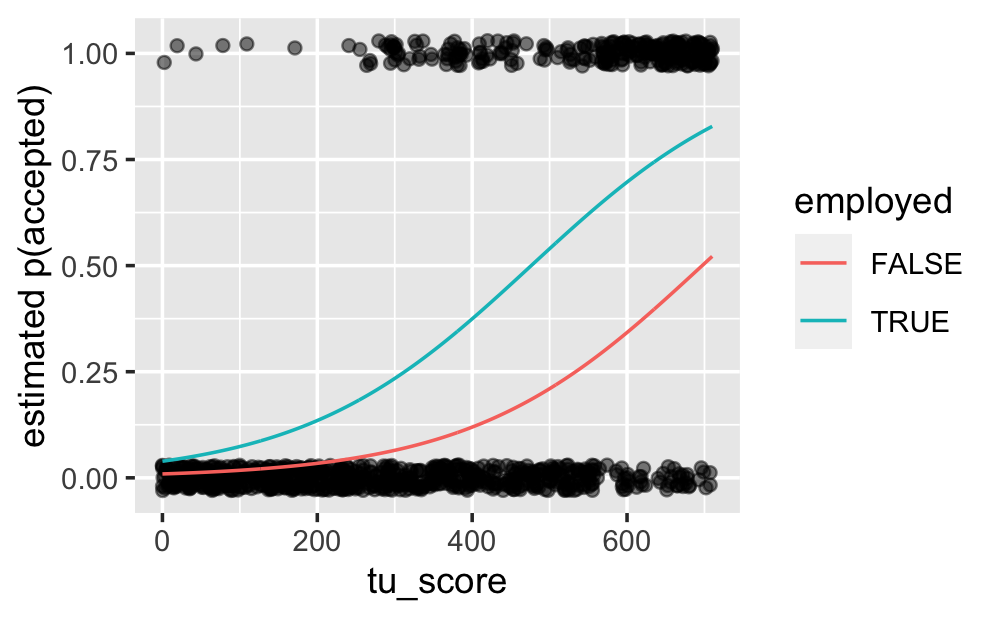

```r
log_pred %>%
  filter(tu_score == 600)
```

| tu_score | employed | pred |
| --- | --- | --- |
| 600 | TRUE | 0.6967935 |
| 600 | FALSE | 0.3424347 |

interpretation of categorical predictors:

odds(employed = true)/ odds(employed = false) = odds ratio

```r
odds_change(1.48,1)
```

```
[1] 4.392946
```

on average, a customer’s odds of being accepted for a mortgage are 4.39

# model performance : building a binary classifier

rather than know the equation of a squiggle and how increasing/decreasing your credit score/ employment affected the probability you’d be accepted for a mortgage

a model that assigns a class based on the predicted probability

if applicant approaches our bank asking for a mortgage, if their credit score is X and their employment is Y, will we accept them for a loan or not

the probability level at which we assign yes or no is called the threshold so for a 0.6 threshold, if the predicted probability of being accepted is greater than 0.6 —> accepted

```r
mortgage_pred <- mortgage%>%
  # add our predicted probability from the log model
  add_predictions(mod_2, type = 'response') %>%
  mutate(predict_accepted = pred >= 0.6)
```

model assessment - how often did we get it right 1 quick assessment tool: The Confusion Matrix

```r
mortgage_pred %>% tabyl(accepted, predict_accepted)
```

```
 accepted FALSE TRUE
    FALSE   678   50
     TRUE    93  179
```

accepted is the y axis Task - 5 mins - Preparation

Load and clean the names of mortgage_applications.csv. Re-run the logistic regression on the dataset, again treating the tu_score, age and employed variables as predictors and the accepted variable as the binary dependent.

Keep the model object (call it mortgage_3pred_model) and use it to predict estimated probabilities for the sample data using add_predictions() (call this mortage_data_with_3pred) Look as the head() of the data with predicted probabilities.

```r
mod_3 <- glm(
  accepted ~ tu_score + employed + age,
  family = binomial(link = 'logit'),
  data = mortgage
)
```

```r
summary(mortgage_pred_3)
```

```
    tu_score      employed            age         accepted
 Min.   :  0.0   Mode :logical   Min.   :18.00   Mode :logical
 1st Qu.:167.8   FALSE:536       1st Qu.:36.75   FALSE:728
 Median :344.0   TRUE :464       Median :46.00   TRUE :272
 Mean   :349.6                   Mean   :46.27
 3rd Qu.:539.2                   3rd Qu.:56.00
 Max.   :710.0                   Max.   :83.00
      pred          predict_accepted
 Min.   :0.008843   Mode :logical
 1st Qu.:0.042242   FALSE:772
 Median :0.118887   TRUE :228
 Mean   :0.272000
 3rd Qu.:0.570125
 Max.   :0.830060
```

```r
mortgage_pred_3 %>% tabyl(accepted, predict_accepted)
```

```
 accepted FALSE TRUE
    FALSE   679   49
     TRUE    93  179
```

Extract the rows in mortgage_data with tu_score = 594. Compare the sample data outcomes with the predicted outcomes of the threshold 0.6 classifier and say which of the following four groups each outcome belongs to: (i) true positive, (ii) true negative, (iii) false positive or (iv) false negative.

```r
 mortgage%>%
  add_predictions(mod_3, type = 'response') %>%
  mutate(predict_accepted = pred >= 0.6) %>%
  filter(tu_score == 594)
```

| tu_score | employed | age | accepted | pred | predict_accepted |
| --- | --- | --- | --- | --- | --- |
| 594 | TRUE | 27 | FALSE | 0.6932743 | TRUE |
| 594 | TRUE | 47 | FALSE | 0.6878897 | TRUE |
| 594 | TRUE | 33 | TRUE | 0.6916643 | TRUE |
| 594 | TRUE | 36 | TRUE | 0.6908576 | TRUE |
| 594 | TRUE | 45 | TRUE | 0.6884305 | TRUE |

what measure of accurancy do we have how do we boil this down into a single value of accuracy

accuracy = nTP + nTN / N (times we are right)/ row

we were correct 85.8 % of the time the bad news is that accuracy has a subtle weakness

consider this case: we run a test at the end of the school year for 1000 students. 900 students pass the test 100 students do not pass

what accuracy would my always pass model get

weakness is’s reaction to unbalanced data

this is why we’ve got other performance measures -accuracy -rate (true positive rate, specificity) -auc -gini

TP Sensitivity rate TN rate T_neg/all negative Specificity (true negative rate) refers to the probability of a negative test, conditioned on truly being negative.

| tu_score | employed | age | accepted | pred | predict_accepted |
| --- | --- | --- | --- | --- | --- |
| 433 | TRUE | 28 | TRUE | 0.433069819 | FALSE |
| 93 | TRUE | 52 | FALSE | 0.069926601 | FALSE |
| 368 | FALSE | 63 | FALSE | 0.096980347 | FALSE |
| 83 | FALSE | 24 | FALSE | 0.016299620 | FALSE |
| 172 | TRUE | 19 | FALSE | 0.117682879 | FALSE |
| 27 | FALSE | 45 | FALSE | 0.010948692 | FALSE |
| 232 | FALSE | 34 | FALSE | 0.042696972 | FALSE |
| 128 | FALSE | 27 | FALSE | 0.021857650 | FALSE |
| 180 | FALSE | 41 | FALSE | 0.030213763 | FALSE |
| 110 | FALSE | 47 | FALSE | 0.018938349 | FALSE |

[output cut: 762 more lines]

772

```r
 mortgage%>%
  add_predictions(mod_3, type = 'response') %>%
  mutate(predict_accepted = pred >= 0.6) %>%
  filter(predict_accepted == FALSE, accepted == FALSE)
```

| tu_score | employed | age | accepted | pred | predict_accepted |
| --- | --- | --- | --- | --- | --- |
| 93 | TRUE | 52 | FALSE | 0.069926601 | FALSE |
| 368 | FALSE | 63 | FALSE | 0.096980347 | FALSE |
| 83 | FALSE | 24 | FALSE | 0.016299620 | FALSE |
| 172 | TRUE | 19 | FALSE | 0.117682879 | FALSE |
| 27 | FALSE | 45 | FALSE | 0.010948692 | FALSE |
| 232 | FALSE | 34 | FALSE | 0.042696972 | FALSE |
| 128 | FALSE | 27 | FALSE | 0.021857650 | FALSE |
| 180 | FALSE | 41 | FALSE | 0.030213763 | FALSE |
| 110 | FALSE | 47 | FALSE | 0.018938349 | FALSE |
| 405 | FALSE | 61 | FALSE | 0.121350652 | FALSE |

[output cut: 669 more lines]

```r
679/772
```

```
[1] 0.8795337
```

False Positive

fp/negtivie

type 1 error rate

FN

TYPE 2 ERROR rate

nTN = 679 nFP = 49 nFN = 93 nTP = 179

tpr = nTP /(nTP + nFN)|(predict-True/ all positive) tnr = nTN/(nTN + nFP)|(predict-False/ all False) fpr = nFP/(nTP + nFN)|(predict-True/) fnr = nFN/(nTN + nFP)